# Factors of Peruvian Copper Exportation

OLS and assumption violations for a time serie

Created by: Eduardo Paredes

3/11/2021

## Data and variables

- Traditional product exports (Thousands of tons). Source BCRP
- Private sector financial account (Millions of US$) - Foreign Direct Investment. Source BCRP
- Copper price (US$ per pound). Source BCRP
- Real Exchange Rate (base 2009=100) - Bilateral. Source BCRP
- Current Price Gross Domestic Product in China, Chinese Yuans, Quarterly, Seasonally Adjusted. Source Federal Reserve Bank of St. Louis (base 2009 = 100)

## Descriptive Statistics

### Unit root test

It is necessary to test if there is unitary roots to include the variables in the specificity of the model.

```
## $volCobre
##
##  Augmented Dickey-Fuller Test
##
## data:  X[[i]]
## Dickey-Fuller = -1.7599, Lag order = 4, p-value = 0.6738
## alternative hypothesis: stationary
##
##
## $fdi
##
##  Augmented Dickey-Fuller Test
##
## data:  X[[i]]
## Dickey-Fuller = -2.6454, Lag order = 4, p-value = 0.3117
## alternative hypothesis: stationary
##
##
## $gdpChina
##
##  Augmented Dickey-Fuller Test
##
## data:  X[[i]]
## Dickey-Fuller = -2.2722, Lag order = 4, p-value = 0.4644
## alternative hypothesis: stationary
##
##
## $copPrice
##
##  Augmented Dickey-Fuller Test
##
## data:  X[[i]]
## Dickey-Fuller = -1.81, Lag order = 4, p-value = 0.6534
## alternative hypothesis: stationary
##
##
## $exchRate
##
##  Augmented Dickey-Fuller Test
##
## data:  X[[i]]
## Dickey-Fuller = -0.59892, Lag order = 4, p-value = 0.9752
## alternative hypothesis: stationary
```

All the variables have unit roots, so they will be changed to percentage variation to evade this problem.

```
## $volCobre_var
##
##  Augmented Dickey-Fuller Test
##
## data:  X[[i]]
## Dickey-Fuller = -3.5972, Lag order = 4, p-value = 0.03916
## alternative hypothesis: stationary
##
##
## $fdi_var
##
##  Augmented Dickey-Fuller Test
##
## data:  X[[i]]
## Dickey-Fuller = -3.6605, Lag order = 4, p-value = 0.03368
## alternative hypothesis: stationary
##
##
## $gdpChina_var
##
##  Augmented Dickey-Fuller Test
##
## data:  X[[i]]
## Dickey-Fuller = -3.5777, Lag order = 4, p-value = 0.04085
## alternative hypothesis: stationary
##
##
## $copPrice_var
##
##  Augmented Dickey-Fuller Test
##
## data:  X[[i]]
## Dickey-Fuller = -3.9842, Lag order = 4, p-value = 0.01477
## alternative hypothesis: stationary
##
##
## $exchRate_var
##
##  Augmented Dickey-Fuller Test
##
## data:  X[[i]]
## Dickey-Fuller = -3.7349, Lag order = 4, p-value = 0.02724
## alternative hypothesis: stationary
```

Now, no variable has unit roots.

### Correlation analysis

Pearson Correlation

|  | volCobre_var | fdi_var | gdpChina_var | copPrice_var | exchRate_var |
| --- | --- | --- | --- | --- | --- |
| volCobre_var | 1.00 | -0.11 | 0.64 | -0.12 | 0.07 |
| fdi_var | -0.11 | 1.00 | -0.18 | 0.06 | -0.25 |
| gdpChina_var | 0.64 | -0.18 | 1.00 | 0.01 | 0.02 |
| copPrice_var | -0.12 | 0.06 | 0.01 | 1.00 | -0.29 |
| exchRate_var | 0.07 | -0.25 | 0.02 | -0.29 | 1.00 |

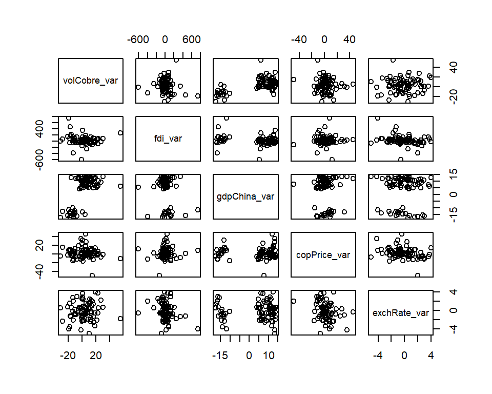

## Econometric Analysis

### Test of Mulitcolinearity

```
##      fdi_var gdpChina_var copPrice_var exchRate_var
##     1.102454     1.034475     1.094601     1.163692
```

### Autocorrelation

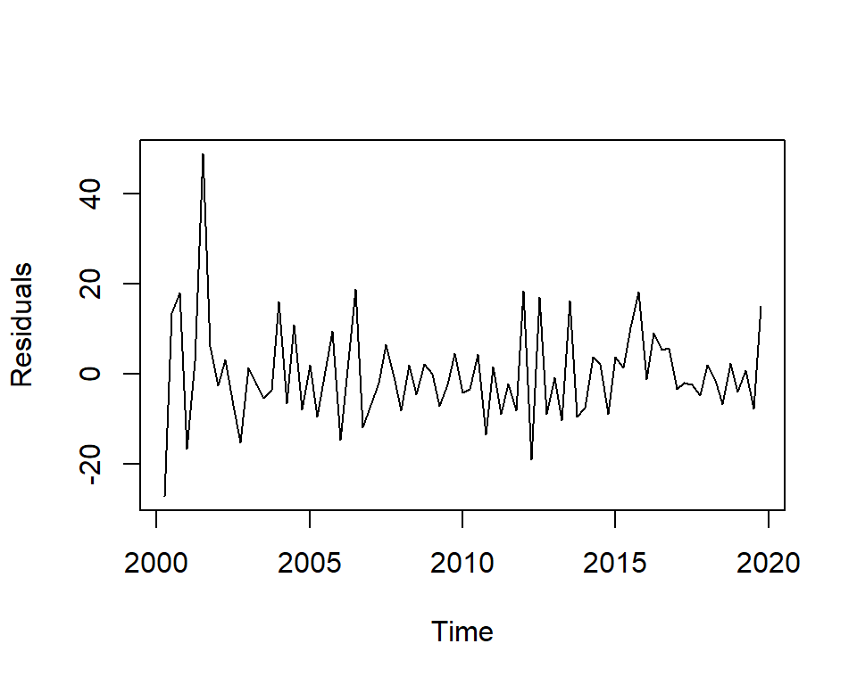

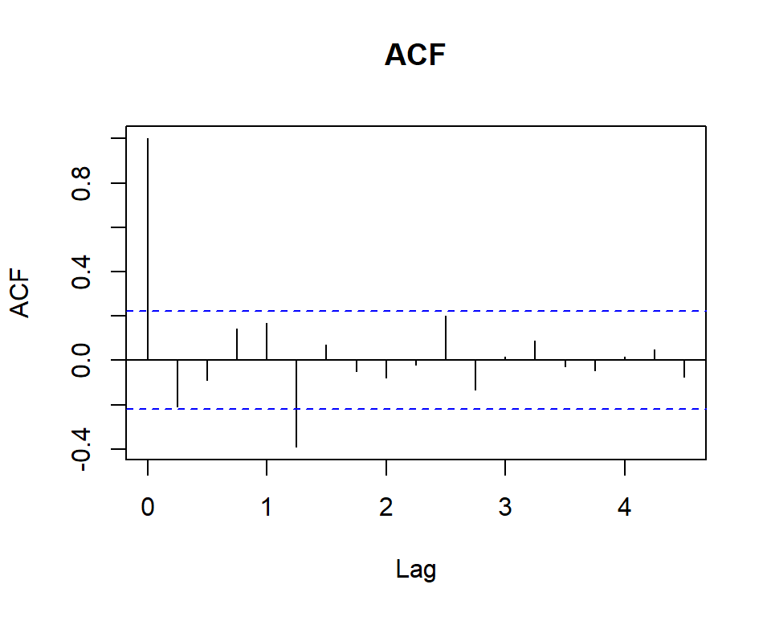

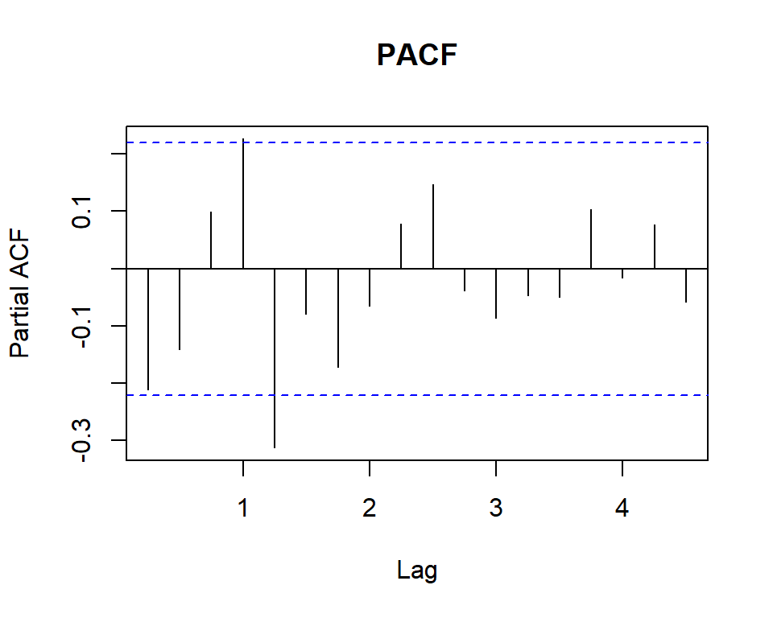

```
##
##  Durbin-Watson test
##
## data:  m1
## DW = 2.3143, p-value = 0.9208
## alternative hypothesis: true autocorrelation is greater than 0
```

### Normality

```
##
##  Jarque Bera Test
##
## data:  residuals(m1)
## X-squared = 77.056, df = 2, p-value < 0.00000000000000022
```

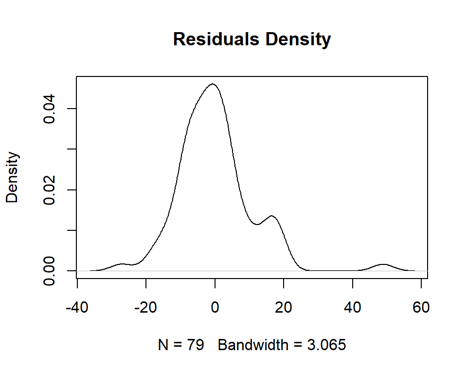

### Heteroskedasticity

```
##
##  studentized Breusch-Pagan test
##
## data:  m1
## BP = 5.7969, df = 4, p-value = 0.2148
```

### Inestability

```
##
##  M-fluctuation test
##
## data:  m1
## f(efp) = 1.002, p-value = 0.7896
```

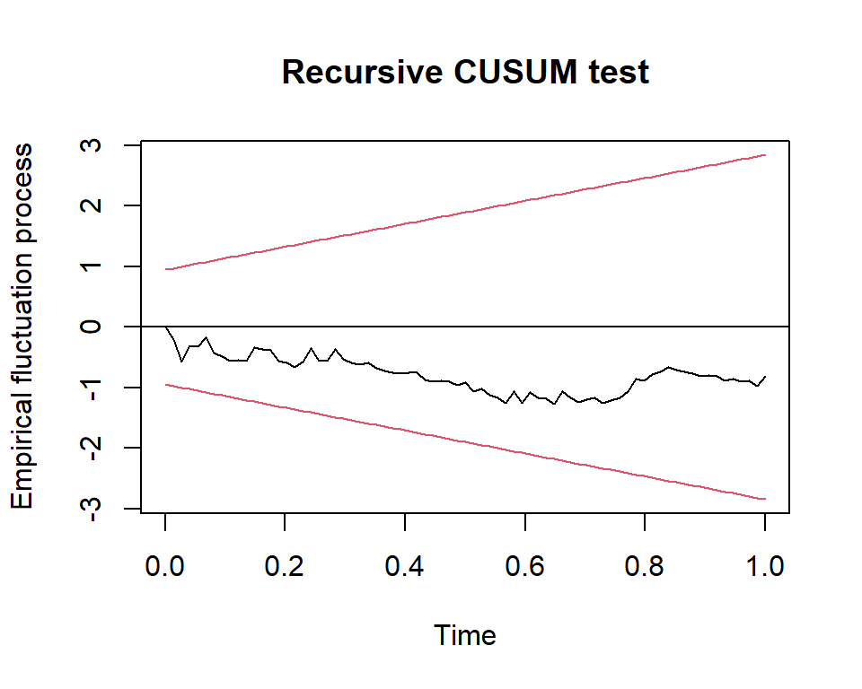